# Homework #4

**See Canvas for HW #4 assignment due date**. Complete all of the following problems. Ideally, the theoretical problems should be answered in a Markdown cell directly underneath the question. If you don't know LaTex/Markdown, you may submit separate handwritten solutions to the theoretical problems. Please do not turn in messy work. Computational problems should be completed in this notebook (using the R kernel is preferred). Computational questions may require code, plots, analysis, interpretation, etc. Working in small groups is allowed, but it is important that you make an effort to master the material and hand in your own work.

## Problem A.1 Causality (15 points)

**Please answer the following three questions. Each answer should be clearly labeled, and a few sentences to a paragraph long.**

1. In your own words, describe the fundamental problem of causal inference. How is this problem related to the counterfactual definition of causality?
1. Describe the use of "close substitutes" as a solution to the fundamental problem of causal inference. How does this solve the problem?
1. What is the difference between a *deterministic* theory of causality and a *probabilistic* theory of causality?

1.) The fundemental problem of causal inference is that it is difficult to observe potential outcomes because their can be different relatas, many relatas that can affect the cause, and usually only one outcome is realized. Therefore, causal effects cannot be measured directly. Causality is a relation that is linked to a unit, i.e. firm, country, person, et cetera. The issue is, is that the unit could have been exposed to alternative actions, however, only one outcome is realized (recieving or not recieving the alternate action). The counterfactual is the non-observable or non-realized outcome that could have happened but didn't.

2.) Close substitutes is a solution where one can actually measure both results on the same unit. For example, comparing my body's BMI before I started running and my BMI after I began running. The assumption is that the pre-treament measure can act as a substitute for the potential outcome. This can possibly solve the problem because we can find reasonably close substitutes and compare the outcomes. But, this can also lead to misconstrued outcomes because the effects are not totally the same.

3.) Determnistic theory of causality is the effect directly follows from the cause. Namely, if your skin touches fire, you will have a burn. Probabilistic theory of causality is the existence of a cause impacts the probability of an effect. So, if I roll a die, chances are that I might roll a one. Where deterministic is saying, if I roll a die I will roll a 1.

## Problem A.2 Causal inference and ethics (20 Points)

How we think about causality, and the statistical models that we use to learn about causal relationships, have ethical implications. The goal of this problem is to invite you to think through some of those issues and implications.

Statisticians, data scientists, researchers, etc., are not in agreement on the best ways to study and analyze important social problems, such as racial discrimination in the criminal justice system. Lily Hu, a PhD candidate in applied math and philosophy at Harvard, recently [wrote](https://lpeproject.org/blog/law-liberation-and-causal-inference/) that disagreements about how to best study these problems "well illustrate how the nuts and bolts of causal inference...about the ...'effects of race'...feature a slurry of theoretical, empirical, and normative reasoning that is often displaced into debates about purely technical matters in methodology."

Here are some resources that enter into or comment on this debate:

1. [Statistical controversy on estimating racial bias in the criminal justice system](https://statmodeling.stat.columbia.edu/2020/07/06/statistical-controversy-on-racial-bias-in-the-criminal-justice-system/)
2. [Can Racial Bias in Policing Be Credibly Estimated Using Data Contaminated by Post-Treatment Selection?](https://dcknox.github.io/files/KnoxLoweMummolo_PostTreatmentSelectionPolicing.pdf)
3. [A Causal Framework for Observational Studies of Discrimination](https://5harad.com/papers/post-treatment-bias.pdf)

**Please read Lily Hu's [blog post](https://lpeproject.org/blog/law-liberation-and-causal-inference/) and Andrew Gelman's blog post ["Statistical controversy on estimating racial bias in the criminal justice system"](https://statmodeling.stat.columbia.edu/2020/07/06/statistical-controversy-on-racial-bias-in-the-criminal-justice-system/) (and feel free to continue on with the other two papers!) to familiarize yourself with some of the issues in this debate. Then, write a short essay (250-500 words) summarizing this debate. Some importan items to consider:**

1. How does the "fundamental problem of causal inference" present itself in these discussions?
1. What are some "possible distortionary effect[s] of using arrest data from administrative police records to measure causal effects of race"? (See Lily Hu's blog post for this quote.)
1. What role do assumptions (both statistical and otherwise) play in this debate? To what extent are assumptions made by different researchers falsifiable?

I myself ask this question very much; would some of my friends and family be arrested if they had been a different race? There is so much to unload in that question, however, I think another factor is the enviroment and community one is raised in. Yes, we can toss around the idea - if that person wasn't of 'this' race and then 'something else' would have happened -however, we are not sure what could have happened. The debate revolves around racially biased policing and how researchers often seek to estimate a causal effect of race or gender on outcomes and how adminstrative records veil racially biased policing.

Presume we are studying racial discrimination outcomes between whites and blacks adjusting for other variables (such as maturing in the same community/social class). The fundemental problem of causal inference presents itself when Knox argues that analyses using adminstrative data are implicitly conditioning on post-treatment variable because they subset on whether you were stopped or not. Therefore administrative records can mask racially biased policing.

Some possible distortionary effects of using arrest data from administrative police records to measure causal effects of race is police adminstrative records lack information on civilians police observed but did not investigate. This can create causal inference mistakes. One must becareful what he/she is conditioning on because lack of information can lead to wrong results.

Assumptions are a huge role in policing because statistically we must be aware of our limitations of our data and understanding the right assumption to be conditioning on. Socially, we cant assume that some one should be arrested becuase they are black, latino, or white. The extent to where assumption are falsifiable is when you are conditioning on variables that are affected by race, estimating effects of discrimination using basic causal regression. Quantifying discrimination at any one point does not reflect specific or cumulative discrimination at other stages.

## B. Computational Problems

## Problem B.1 (24 Points for STAT 4010, 34 Points for STAT 5010)

#### For the [`teengamb`](https://rdrr.io/cran/faraway/man/teengamb.html) data, fit a model with `gamble` as the response and the other variables as predictors. Look for violations of:

1. Constant Variance (8 points)
2. Normality (8 points)
3. Linearity (8 points)
4. **STAT 5510 Only (10 points): Look for (a) outliers, (b) leverage points, and (b) potentially influential points. This part of the problem requires some self-study about defining and identifying leverage points, and describing the relationship between leverage and influence. Chapter 6 of *Linear Models with R* (pdf on Canvas) may help!**

#### Write a short report detailing your findings.

```
	Shapiro-Wilk normality test

data:  dfDiag$resid
W = 0.86839, p-value = 8.16e-05
```

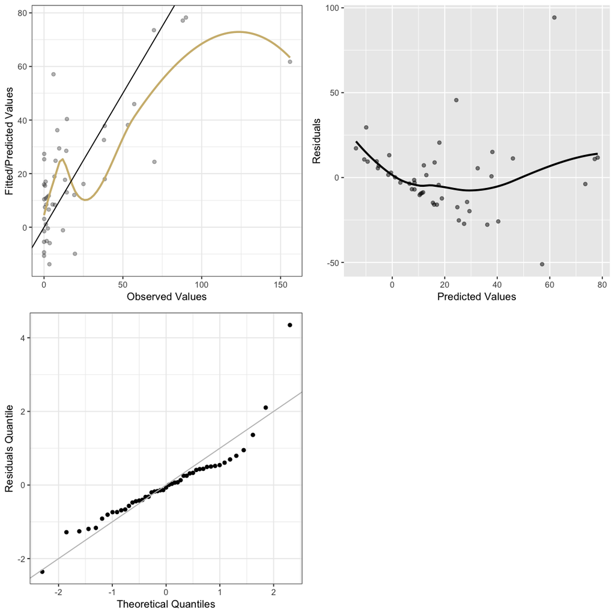

```r
library(faraway) #this package contains the teengamb data. If you have trouble downloading this
library(ggplot2) #package, you can also find the data on Canvas.
library(gridExtra)

data(teengamb)


lm_teen = lm(gamble ~ verbal +  income+ status + sex, teengamb)

dfDiag = data.frame(yhat = fitted(lm_teen), resid = resid(lm_teen), y = teengamb$gamble, verbal = teengamb$verbal,
                   income = teengamb$income, status = teengamb$status, sex = teengamb$sex, lev = hatvalues(lm_teen),
                   stdresid = rstandard(lm_teen), cook = cooks.distance(lm_teen))
options(repr.plot.width = 9, repr.plot.height = 9)

p1 = ggplot(dfDiag, aes(x = y, y = yhat)) +
    geom_point(alpha = 0.3) +
    geom_smooth(se = F, col = "#CFB87C") +
    geom_abline(intercept = 0, slope = 1) +
    xlab("Observed Values") +
    ylab("Fitted/Predicted Values") +
    theme_bw()
p2 = ggplot(dfDiag, aes(x = yhat, y = resid)) +
    geom_point(alpha = 0.5) +
    geom_smooth(se = F, col = "black") +
    xlab("Predicted Values") +
    ylab("Residuals")
p3 = ggplot(dfDiag, aes(sample = (resid-mean(resid))/sd(resid))) +
    stat_qq() + geom_abline(slope = 1, intercept = 0, col = "grey") +
    xlab("Theoretical Quantiles") + ylab("Residuals Quantile") + theme_bw()

shapiro.test(dfDiag$resid)
grid.arrange(p1, p2, p3, nrow=2, ncol = 2)
```

The predicted vs the observed value plot should follow the black line, $y = x$ with random deviations, however, notice that for observed values greater than $15$ the model is underpredicting. Similarly, for values between $5$ and $10$ the model is overpredicting with a more variability. What is also effecting our model is the outlier at $150$. It could be an anomoly because if we were to remove it I think the model would not curve as much. Moreover, our model seems to be polynomial therefore violating the linearity assumption. Nevertheless lets continue on the residual vs predicted value plot.

Look at the residuals vs predicted values plot, I support my previous case. It seems that we are having some nonconstant variance because of the curvature of the graph. Also, there is a non-linear type of structure therefore making the plot difficult to use to asses normality assumption. I would argue that it is difficult to show violation of constant varaince. The best I can say to a violation of constant variance is as the predicted values increase we are showing more scatter hence more variability. Lastly, it does support my statement of violation of linearity because of the parabola type of curve.

In the quantile graph points seem to fall off at the beginning and end of the plot. It looks like we have two outliers that are causing the point to regress to the linear line. Overall I would say there is violation towards the normality assumption because we heavy tails at both ends of the graph. Also, from the shapiro test, the p-values is less then $\alpha = 0.05$ thereferoe we have evidence that the residuals came from a non-normal distribution.

Overall from the predicted vs observed value plots we notice some violation of constant variance because as the points increase the is more variance. Also, we have violation of linearity because our model has a polynomial trend and this can be corroborated with our second graph - residuals vs predicted values plot. Our last plot quantile plot shows us the data violates the normality assumption which is also shown by the shapiro test.

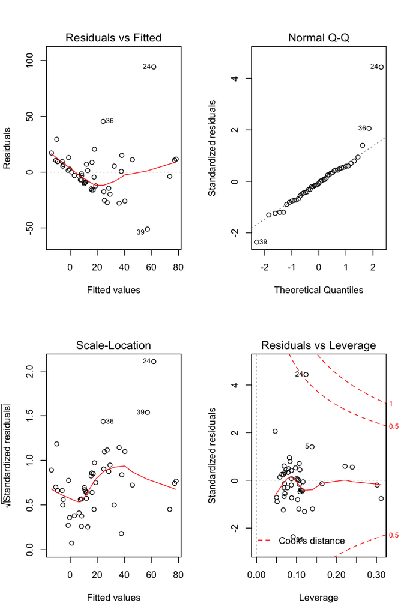

```r
options(repr.plot.width = 6, repr.plot.width = 6)
par(mfrow = c(2,2))
plot(lm_teen)
```

## Problem B.2 (41 Points)

Researchers at the National Institutes of Standards and Technology (NIST) collected [pipline data](https://rdrr.io/cran/faraway/man/pipeline.html) on ultrasonic measurements of the depth of defects in the Alaska pipeline in the field. The depths of the defects were then remeasured in the laboratory. The laboratory measurements are more accurate than the field measurements, but more time consuming and expensive. We want to develop a regression model for correcting the in field measurements.

#### (a) (10 points) Fit a regression model where `Lab` is the response and `Field` is the predictor and save this model as `lmodPipeline`. Check for non-constant variance.

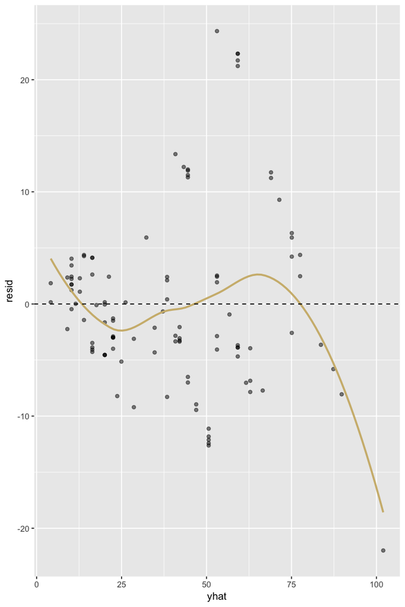

```
Call:
lm(formula = Lab ~ Field, data = pipeline)

Residuals:
    Min      1Q  Median      3Q     Max
-21.985  -4.072  -1.431   2.504  24.334

Coefficients:
            Estimate Std. Error t value Pr(>|t|)
(Intercept) -1.96750    1.57479  -1.249    0.214
Field        1.22297    0.04107  29.778   <2e-16 ***
---
Signif. codes:  0 ‘***’ 0.001 ‘**’ 0.01 ‘*’ 0.05 ‘.’ 0.1 ‘ ’ 1

Residual standard error: 7.865 on 105 degrees of freedom
Multiple R-squared:  0.8941,	Adjusted R-squared:  0.8931
F-statistic: 886.7 on 1 and 105 DF,  p-value: < 2.2e-16
```

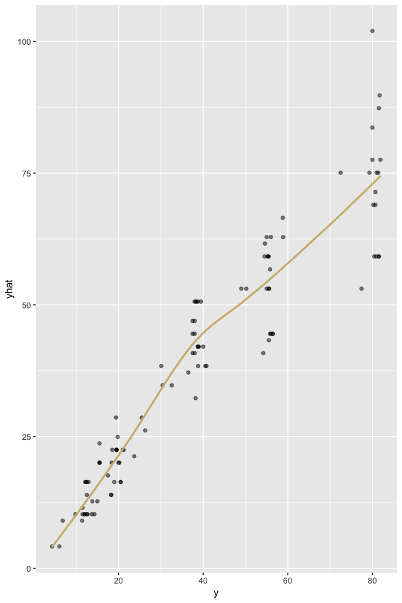

```r
library(faraway) #this package contains the pipeline data. If you have trouble downloading this
                    #package, you can also find the data on Canvas.

lmodPipeline = lm(Lab ~ Field, pipeline)

dfnostic = data.frame(yhat = fitted(lmodPipeline), resid = resid(lmodPipeline),
                      y = pipeline$Lab)
ggplot(dfnostic, aes(x = yhat, y = resid)) +
    geom_point(alpha = 0.5) +
    geom_smooth(se = F, col = "#CFB87C") +
    geom_hline(yintercept = 0, linetype = "dashed");

ggplot(dfnostic, aes(x = y, y = yhat)) +
    geom_point(alpha = 0.5) +
    geom_smooth(se = F, col = "#CFB87C")

summary(lmodPipeline)
```

From the Residuals vs predicted value plot it does seem to show nonconstant variance. There is a cubic curvature and points seem to be scatter non-consistently. We have points out at the end, but, these points can be considered outliers.

#### (b) (10 points) Sometimes transforming the response and predictor helps in stabilizing variance. Find a transformation on Lab and/or Field so that in the transformed scale the relationship is approximately linear with constant variance. Restrict your choice of transformation to square root, log, and inverse. Save your transformed variables as `pipeline$LabTransform` and `pipeline$FieldTransform`. Then, regress the transformed`Lab` variable (repsonse) onto the transformed `Field` variable (predictor), and save this as `lmodTr`.

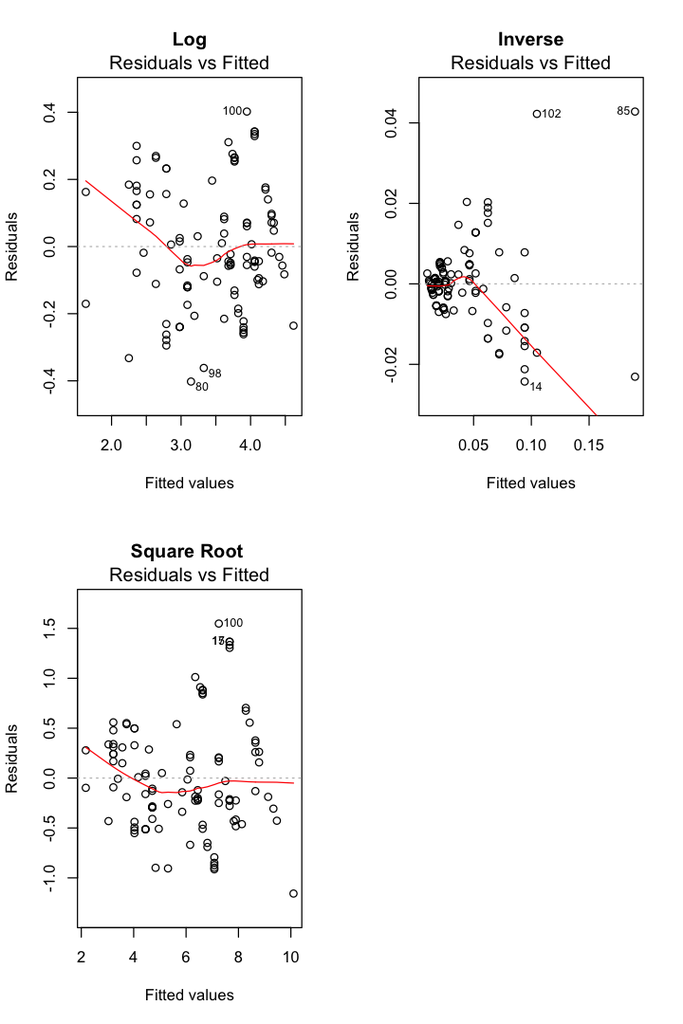

```r
# Log
pipeline$LabTransform = log(pipeline$Lab)
pipeline$FieldTransform = log(pipeline$Field)

lmodTr1 =lm(LabTransform ~ FieldTransform, pipeline)

# Inverse
pipeline$LabTransform = 1/pipeline$Lab
pipeline$FieldTransform = 1/pipeline$Field

lmodTr2 =lm(LabTransform ~ FieldTransform, pipeline)

# Square Root
pipeline$LabTransform = sqrt(pipeline$Lab)
pipeline$FieldTransform = sqrt(pipeline$Field)

lmodTr3 =lm(LabTransform ~ FieldTransform, pipeline)

par(mfrow = c(2,2))
plot(lmodTr1, which = c(1), main = "Log")
plot(lmodTr2, which = c(1), main ="Inverse")
plot(lmodTr3, which = c(1), main = "Square Root ")

# Saved model is the square root model
lmodTr = lmodTr3
```

#### (c) (5 points) Now let's try weighted least squares. The code below splits the range of `Field` into 12 groups of size nine (except for the last goup which has only eight values). Within each group, we compute the variance of `Lab` as varlab and the mean of `Field` as meanfield. Write comments for each line of the code to demonstrate what each line is doing.

```r
i = order(pipeline$Field);
npipe = pipeline[i,];
ff = gl(12,9)[-108];
meanfield = unlist(lapply(split(npipe$Field,ff),mean));
varlab = unlist(lapply(split(npipe$Lab,ff),var));
```

```r
# i, order's the Field col in ascending order
# npipe is the rows order in respect to Field
# gl generates the group of 12 starting from 1,...,12 in size 9 (except last group is 8)
# meanfield is the weighted mean point for each group of 9
# varlab is the weighted variance point for each group of 9
```

#### (d) (16 points) Suppose that the variance in the repsonse is linked to the predictor in the following way: $$ Var(Lab) = a_0Field^{a_1}.$$ Use simple linear regression on (transformations of) varlab and meanfield to estimate $a_0$ and $a_1$. Call this regression `lmodVar`.Use these estimates to perform weighted least squares where the weights are the inverse of the variance of Lab. Call this regression `lmodwls`. Print a summary of this model and comment on the fit.

```r
wghted = data.frame(var = log(varlab), mean = log(meanfield));
lmodVar = lm(var ~ mean, wghted)
smryVar = summary(lmodVar)
```

```r
a0 = smryVar$coefficients[1]
a1 = smryVar$coefficients[2]

varlabs = exp(a0)*(pipeline$Field)^a1


lmodwls = lm(Lab ~ Field, pipeline, weights = 1/varlabs)
```

```
Call:
lm(formula = Lab ~ Field, data = pipeline, weights = 1/varlabs)

Weighted Residuals:
    Min      1Q  Median      3Q     Max
-2.0826 -0.8102 -0.3189  0.6212  3.4429

Coefficients:
            Estimate Std. Error t value Pr(>|t|)
(Intercept) -1.49436    0.90707  -1.647    0.102
Field        1.20828    0.03488  34.637   <2e-16 ***
---
Signif. codes:  0 ‘***’ 0.001 ‘**’ 0.01 ‘*’ 0.05 ‘.’ 0.1 ‘ ’ 1

Residual standard error: 1.169 on 105 degrees of freedom
Multiple R-squared:  0.9195,	Adjusted R-squared:  0.9188
F-statistic:  1200 on 1 and 105 DF,  p-value: < 2.2e-16
```

```
Call:
lm(formula = Lab ~ Field, data = pipeline)

Residuals:
    Min      1Q  Median      3Q     Max
-21.985  -4.072  -1.431   2.504  24.334

Coefficients:
            Estimate Std. Error t value Pr(>|t|)
(Intercept) -1.96750    1.57479  -1.249    0.214
Field        1.22297    0.04107  29.778   <2e-16 ***
---
Signif. codes:  0 ‘***’ 0.001 ‘**’ 0.01 ‘*’ 0.05 ‘.’ 0.1 ‘ ’ 1

Residual standard error: 7.865 on 105 degrees of freedom
Multiple R-squared:  0.8941,	Adjusted R-squared:  0.8931
F-statistic: 886.7 on 1 and 105 DF,  p-value: < 2.2e-16
```

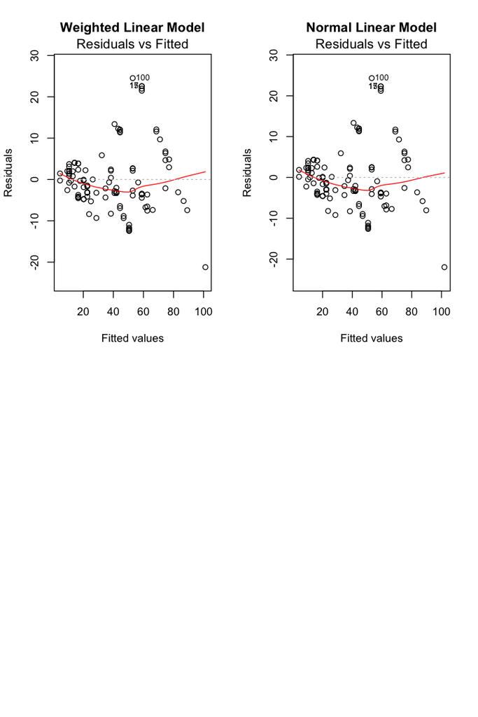

```r
summary(lmodwls)
summary(lmodPipeline)
par(mfrow = c(2,2))
plot(lmodwls, which = c(1), main = "Weighted Linear Model")
plot(lmodPipeline, which = c(1), main = "Normal Linear Model")
```

First note that the linear model `lmodwls` has increased $\beta_0$ and decreased $\beta_1$ compared to `lmodPipeline`. The intercept for `lmodwls` indubitably increased and the std. error decreased significantly. Also notice that the weighted residuals are a magnitude lower than the normal residuals. However, when I print out the residuals vs fitted value plot, both plots look exactly the same. The t-value increased for `lmodwls` in both coefficients and the p-value decreased for the $\beta_0$. `lmodwls`s $R^2$ increased hence I believe the `lmodwls` is a better model.